# JUMP Cell Painting cpg0016 CPCNN Embedding MAE v1.1

Michael Tran

2026-03-31

This notebook demonstrates the structure and basic use of JUMP Cell Painting cpg0016 CPCNN Embedding MAE v1.1, a `MultiAssayExperiment` containing well-level Cell Painting embeddings and compound annotations.

## Load the MAE

```r
mae <- readRDS(mae_path)
embedding_se <- experiments(mae)[["all_emb"]]
embedding_mat <- assay(embedding_se, "embedding")
dataset_name <- metadata(mae)$dataset_name
dataset_version <- metadata(mae)$dataset_version
dataset_label <- paste(dataset_name, dataset_version)

well_metadata <- as.data.frame(colData(mae)) |>
  rownames_to_column("sample_id") |>
  as_tibble()

compound_metadata <- as.data.frame(metadata(mae)$compound_metadata) |>
  as_tibble()

mae
```

```
## A MultiAssayExperiment object of 1 listed
##  experiment with a user-defined name and respective class.
##  Containing an ExperimentList class object of length 1:
##  [1] all_emb: SummarizedExperiment with 672 rows and 793683 columns
## Functionality:
##  experiments() - obtain the ExperimentList instance
##  colData() - the primary/phenotype DataFrame
##  sampleMap() - the sample coordination DataFrame
##  `$`, `[`, `[[` - extract colData columns, subset, or experiment
##  *Format() - convert into a long or wide DataFrame
##  assays() - convert ExperimentList to a SimpleList of matrices
##  exportClass() - save data to flat files
```

## Dataset Overview

```r
perturbation_counts <- well_metadata |>
  count(Metadata_pert_type, name = "wells", sort = TRUE)

overview_tbl <- tibble(
  quantity = c(
    "Experiments",
    "Assay name",
    "Embedding dimensions",
    "Wells",
    "Plates",
    "Sources",
    "Unique compounds",
    "Treatment wells",
    "Negative-control wells",
    "Positive-control wells"
  ),
  value = c(
    length(experiments(mae)),
    paste(assayNames(embedding_se), collapse = ", "),
    scales::comma(nrow(embedding_mat)),
    scales::comma(ncol(embedding_mat)),
    scales::comma(n_distinct(well_metadata$Metadata_Plate)),
    scales::comma(n_distinct(well_metadata$Metadata_Source)),
    scales::comma(n_distinct(well_metadata$Metadata_JCP2022)),
    scales::comma(sum(well_metadata$Metadata_pert_type == "treatment")),
    scales::comma(sum(well_metadata$Metadata_pert_type == "negcon")),
    scales::comma(sum(well_metadata$Metadata_pert_type == "poscon"))
  )
)

kable(overview_tbl)
```

| quantity | value |
| --- | --- |
| Experiments | 1 |
| Assay name | embedding |
| Embedding dimensions | 672 |
| Wells | 793,683 |
| Plates | 1,729 |
| Sources | 10 |
| Unique compounds | 115,730 |
| Treatment wells | 642,139 |
| Negative-control wells | 88,556 |
| Positive-control wells | 62,988 |

JUMP Cell Painting cpg0016 CPCNN Embedding MAE v1.1 contains 793,683 wells as columns of a single embedding assay named `embedding`. Each well has a 672-dimensional feature vector and a matching row in `colData(mae)`.

## Inspect the MAE Structure

The object layout is inspected directly below. The experiment container, assay name, dataset label, well-level metadata, and object-level metadata can all be accessed from the printed structure and the code shown in this section.

```r
mae
```

```
## A MultiAssayExperiment object of 1 listed
##  experiment with a user-defined name and respective class.
##  Containing an ExperimentList class object of length 1:
##  [1] all_emb: SummarizedExperiment with 672 rows and 793683 columns
## Functionality:
##  experiments() - obtain the ExperimentList instance
##  colData() - the primary/phenotype DataFrame
##  sampleMap() - the sample coordination DataFrame
##  `$`, `[`, `[[` - extract colData columns, subset, or experiment
##  *Format() - convert into a long or wide DataFrame
##  assays() - convert ExperimentList to a SimpleList of matrices
##  exportClass() - save data to flat files
```

```r
experiments(mae)
```

```
## ExperimentList class object of length 1:
##  [1] all_emb: SummarizedExperiment with 672 rows and 793683 columns
```

```r
metadata(mae)[c("dataset_name", "dataset_version", "compound_metadata_key")]
```

```
## $dataset_name
## [1] "JUMP Cell Painting cpg0016 CPCNN Embedding MAE"
##
## $dataset_version
## [1] "v1.1"
##
## $compound_metadata_key
## [1] "JUMP.CP.ID"
```

```r
colnames(colData(mae))
```

```
## [1] "Metadata_Source"    "Metadata_Batch"     "Metadata_Plate"
## [4] "Metadata_Well"      "Metadata_JCP2022"   "Metadata_InChIKey"
## [7] "Metadata_pert_type"
```

```r
names(metadata(mae))
```

```
##  [1] "dataset_name"          "dataset_version"       "profile_model"
##  [4] "model_stem"            "embedding_columns"     "embedding_lengths"
##  [7] "pipeline_config"       "manifest"              "manifest_summary"
## [10] "compound_metadata_key" "compound_metadata"
```

## Well-Level Metadata

```r
kable(head(well_metadata, 8))
```

| sample_id | Metadata_Source | Metadata_Batch | Metadata_Plate | Metadata_Well | Metadata_JCP2022 | Metadata_InChIKey | Metadata_pert_type |
| --- | --- | --- | --- | --- | --- | --- | --- |
| CP4-SC1-17.A13 | source_7 | 20210731_Run4 | CP4-SC1-17 | A13 | JCP2022_041519 | JQSRUVXPODZKAF-UHFFFAOYSA-N | treatment |
| CP1-SC1-21.E05 | source_7 | 20210719_Run1 | CP1-SC1-21 | E05 | JCP2022_059635 | NKOTUQPBTKXMQO-UHFFFAOYSA-N | treatment |
| GR00004412.A27 | source_9 | 20211103-Run16 | GR00004412 | A27 | JCP2022_006246 | BGTNTJYDLGJMHV-UHFFFAOYSA-N | treatment |
| UL001769.P34 | source_1 | Batch4_20221012 | UL001769 | P34 | JCP2022_114690 | ZOSXZYNSEHOBAO-UHFFFAOYSA-N | treatment |
| CP3-SC1-04.I09 | source_7 | 20210727_Run3 | CP3-SC1-04 | I09 | JCP2022_097094 | VYFYYTLLBUKUHU-UHFFFAOYSA-N | treatment |
| Dest210622-143006.M07 | source_10 | 2021_06_22_U2OS_48_hr_run8 | Dest210622-143006 | M07 | JCP2022_017003 | DNJATZDBTBSXML-UHFFFAOYSA-N | treatment |
| GR00003286.N10 | source_9 | 20211013-Run14 | GR00003286 | N10 | JCP2022_043897 | KDLVYURNHIOMKF-UHFFFAOYSA-N | treatment |
| UL001795.H23 | source_1 | Batch5_20221030 | UL001795 | H23 | JCP2022_046153 | KPNIHJVKPJYDSL-UHFFFAOYSA-N | treatment |

The main fields commonly used in downstream analysis are:

- `sample_id`: the well identifier used throughout the object. It is the row name of `colData(mae)` and the column name of the embedding matrix.
- `Metadata_Source`: the source-specific study label.
- `Metadata_Batch`: the batch identifier within a source.
- `Metadata_Plate` and `Metadata_Well`: the physical plate and well coordinates.
- `Metadata_JCP2022`: the perturbagen identifier used to join to compound metadata, where the public alias `JUMP.CP.ID` is also available.
- `Metadata_InChIKey`: the structure-level identifier for the perturbagen.
- `Metadata_pert_type`: whether the well is a treatment, negative control (`negcon`), or positive control (`poscon`).

```r
kable(perturbation_counts)
```

| Metadata_pert_type | wells |
| --- | --- |
| treatment | 642139 |
| negcon | 88556 |
| poscon | 62988 |

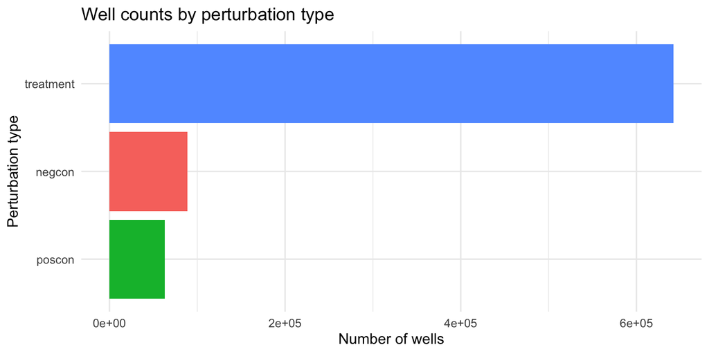

```r
ggplot(
  perturbation_counts,
  aes(
    x = reorder(Metadata_pert_type, wells),
    y = wells,
    fill = Metadata_pert_type
  )
) +
  geom_col(show.legend = FALSE) +
  labs(
    title = "Well counts by perturbation type",
    x = "Perturbation type",
    y = "Number of wells"
  ) +
  coord_flip()
```

## Inspect the Embedding Assay

```r
kable(head(as.data.frame(rowData(embedding_se)), 3))
```

| feature_index | embedding_name | profile_model |
| --- | --- | --- |
| 1 | all_emb | cpcnn_zenodo_7114558 |
| 2 | all_emb | cpcnn_zenodo_7114558 |
| 3 | all_emb | cpcnn_zenodo_7114558 |

```r
dim(rowData(embedding_se))
```

```
## [1] 672   3
```

`all_emb` is a `SummarizedExperiment` with one assay called `embedding`. Rows are embedding features and columns are wells.

```r
tibble(
  metric = c("Embedding features per well", "Wells in assay"),
  value = c(nrow(embedding_mat), ncol(embedding_mat))
) |>
  kable()
```

| metric | value |
| --- | --- |
| Embedding features per well | 672 |
| Wells in assay | 793683 |

```r
embedding_mat[1:6, 1:4]
```

```
##      CP4-SC1-17.A13 CP1-SC1-21.E05 GR00004412.A27 UL001769.P34
## [1,]      0.7846164      0.9088950       1.217037    1.1983480
## [2,]      2.4524574      2.3928332       2.573188    2.7184100
## [3,]      2.9531357      2.9322929       1.739103    1.5024635
## [4,]      1.8645332      2.0388241       1.734603    2.0873072
## [5,]      2.0057428      2.1586680       2.003108    2.0476625
## [6,]      0.5371428      0.5223227       2.550724    0.7752874
```

The matrix and metadata are aligned by `sample_id`.

```r
identical(colnames(embedding_mat), well_metadata$sample_id)
```

```
## [1] TRUE
```

## Compound Metadata

```r
compound_preview <- compound_metadata |>
  select(
    `JUMP.CP.ID`,
    Metadata_JCP2022,
    InChIKey,
    Metadata_pert_type,
    Molecule.Name,
    Pubchem.CID,
    `In.JUMP.CP`,
    In_AnnotationDB
  ) |>
  slice_head(n = 8)

kable(compound_preview)
```

| JUMP.CP.ID | Metadata_JCP2022 | InChIKey | Metadata_pert_type | Molecule.Name | Pubchem.CID | In.JUMP.CP | In_AnnotationDB |
| --- | --- | --- | --- | --- | --- | --- | --- |
| JCP2022_000001 | JCP2022_000001 | AAAHWCWPZPSPIW-UHFFFAOYSA-N | treatment | [4-[2-(Dimethylamino)ethoxy]phenyl]-[2-[6-(2-ethylimidazol-1-yl)-2-pyridinyl]pyrrolidin-1-yl]methanone | 110094592 | TRUE | TRUE |
| JCP2022_000002 | JCP2022_000002 | AAAJHRMBUHXWLD-UHFFFAOYSA-N | treatment | 1-(4-chlorobenzyl)tetrahydropyrimidin-2(1H)-one | 5076487 | TRUE | TRUE |
| JCP2022_000004 | JCP2022_000004 | AAANUZMCJQUYNX-UHFFFAOYSA-N | treatment | NA | NA | TRUE | FALSE |
| JCP2022_000005 | JCP2022_000005 | AAAQFGUYHFJNHI-UHFFFAOYSA-N | treatment | 4H-[1,2,4]Triazolo[4,3-a][1,4]benzodiazepine-4-acetamide, 6-(4-chlorophenyl)-N-ethyl-8-methoxy-1-methyl- | 52934829 | TRUE | TRUE |
| JCP2022_000006 | JCP2022_000006 | AAAROXVLYNJINN-UHFFFAOYSA-N | treatment | 5-(1-Tert-butyl-5-cyclopropylpyrazol-3-yl)-3-(1-methylpyrazol-4-yl)-1,2,4-oxadiazole | 72019641 | TRUE | TRUE |
| JCP2022_000007 | JCP2022_000007 | AAATVJFGQAZXQO-UHFFFAOYSA-N | treatment | [1-(1H-indol-3-yl)-1-oxopropan-2-yl] 2-[(3,5-dimethyl-1,2-oxazol-4-yl)methylsulfanyl]benzoate | 16324273 | TRUE | TRUE |
| JCP2022_000008 | JCP2022_000008 | AAAUIKUIDRZZQT-UHFFFAOYSA-N | treatment | N-(3-chlorophenyl)-2-(3-methyl-2-oxo-5-phenyl-2,3-dihydro-1H-1,4-benzodiazepin-1-yl)butanamide | 15998487 | TRUE | TRUE |
| JCP2022_000009 | JCP2022_000009 | AAAZRMGPBSWFDK-UHFFFAOYSA-N | treatment | 2-(2-(4-(2-(Trifluoromethyl)phenylsulfonyl)piperazin-1-yl)acetamido)thiophene-3-carboxamide | 16231644 | TRUE | TRUE |

This table is stored once at the object level instead of being repeated on every well. The public join key is `JUMP.CP.ID`, and the compatibility alias `Metadata_JCP2022` is retained to simplify joins to the well-level metadata.

The `Metadata_pert_type` labels also appear in the compound metadata. In this context, `negcon` denotes negative controls and `poscon` denotes positive controls.

```r
negcon_examples <- compound_metadata |>
  filter(Metadata_pert_type == "negcon") |>
  select(
    `JUMP.CP.ID`,
    Metadata_Control_Name,
    Molecule.Name,
    Pubchem.CID
  ) |>
  slice_head(n = 3)

poscon_examples <- compound_metadata |>
  filter(Metadata_pert_type == "poscon") |>
  select(
    `JUMP.CP.ID`,
    Metadata_Control_Name,
    Molecule.Name,
    Pubchem.CID
  ) |>
  slice_head(n = 3)

kable(negcon_examples, caption = "Example negative-control compounds")
```

Example negative-control compounds

| JUMP.CP.ID | Metadata_Control_Name | Molecule.Name | Pubchem.CID |
| --- | --- | --- | --- |
| JCP2022_033924 | DMSO | DMSO | 679 |

```r
kable(poscon_examples, caption = "Example positive-control compounds")
```

Example positive-control compounds

| JUMP.CP.ID | Metadata_Control_Name | Molecule.Name | Pubchem.CID |
| --- | --- | --- | --- |
| JCP2022_012818 | TC-S-7004 | TC-S-7004 | 57523919 |
| JCP2022_025848 | dexamethasone | dexamethasone | 90753810 |
| JCP2022_035095 | LY2109761 | LY2109761 | 11655119 |

## Demonstrate Basic Access Patterns

### Pull One Plate and Its Embeddings

```r
plate_id <- well_metadata$Metadata_Plate[1]

plate_wells <- well_metadata |>
  filter(Metadata_Plate == plate_id)

plate_embeddings <- embedding_mat[, plate_wells$sample_id, drop = FALSE]

kable(
  plate_wells |>
    select(
      sample_id,
      Metadata_Well,
      Metadata_JCP2022,
      Metadata_pert_type
    ) |>
    slice_head(n = 8)
)
```

| sample_id | Metadata_Well | Metadata_JCP2022 | Metadata_pert_type |
| --- | --- | --- | --- |
| CP4-SC1-17.A13 | A13 | JCP2022_041519 | treatment |
| CP4-SC1-17.C07 | C07 | JCP2022_017665 | treatment |
| CP4-SC1-17.C24 | C24 | JCP2022_050797 | poscon |
| CP4-SC1-17.O11 | O11 | JCP2022_022234 | treatment |
| CP4-SC1-17.L04 | L04 | JCP2022_031974 | treatment |
| CP4-SC1-17.A09 | A09 | JCP2022_058729 | treatment |
| CP4-SC1-17.N11 | N11 | JCP2022_109812 | treatment |
| CP4-SC1-17.K16 | K16 | JCP2022_057347 | treatment |

```r
dim(plate_embeddings)
```

```
## [1] 672 384
```

### Annotate Wells with Compound Metadata

```r
plate_treatment_wells <- plate_wells |>
  filter(Metadata_pert_type == "treatment")

plate_treatment_annotated <- plate_treatment_wells |>
  transmute(
    sample_id,
    Metadata_Source,
    Metadata_Plate,
    Metadata_Well,
    `JUMP.CP.ID` = Metadata_JCP2022
  ) |>
  left_join(
    compound_metadata |>
      select(
        `JUMP.CP.ID`,
        Molecule.Name,
        Pubchem.CID,
        In_AnnotationDB
      ),
    by = "JUMP.CP.ID"
  )

kable(slice_head(plate_treatment_annotated, n = 8))
```

| sample_id | Metadata_Source | Metadata_Plate | Metadata_Well | JUMP.CP.ID | Molecule.Name | Pubchem.CID | In_AnnotationDB |
| --- | --- | --- | --- | --- | --- | --- | --- |
| CP4-SC1-17.A13 | source_7 | CP4-SC1-17 | A13 | JCP2022_041519 | IRAK inhibitor 6 | 44449392 | TRUE |
| CP4-SC1-17.C07 | source_7 | CP4-SC1-17 | C07 | JCP2022_017665 | N-[3-(3-Amino-1-hydroxy-3-oxopropyl)-6-[1,2-dihydroxy-2-(4-hydroxyphenyl)ethyl]-11,20,21,25-tetrahydroxy-15-(1-hydroxyethyl)-2,5,8,14,17,23-hexaoxo-1,4,7,13,16,22-hexazatricyclo[22.3.0.09,13]heptacosa… | 15115604 | TRUE |
| CP4-SC1-17.O11 | source_7 | CP4-SC1-17 | O11 | JCP2022_022234 | Indirubin-3’-monoxime | 3707 | TRUE |
| CP4-SC1-17.L04 | source_7 | CP4-SC1-17 | L04 | JCP2022_031974 | (5-Methyl-3-(morpholinomethyl)-2,3-dihydro-[1,4]oxazino[2,3,4-hi]indol-6-yl)(naphthalen-1-yl)methanone | 5689 | TRUE |
| CP4-SC1-17.A09 | source_7 | CP4-SC1-17 | A09 | JCP2022_058729 | Spiro[3,5,8-ethanylylidene-1H-pyrano[3,4-c]pyridine-10,3’-[3H]indol]-2’(1’H)-one, 5-ethenyl-3,4,4a,5,6,7,8,8a-octahydro-7-methyl- | 279057 | TRUE |
| CP4-SC1-17.N11 | source_7 | CP4-SC1-17 | N11 | JCP2022_109812 | 6-[[4,4,6a,6b,11,11,14b-Heptamethyl-8a-[3,4,5-trihydroxy-6-(hydroxymethyl)oxan-2-yl]oxycarbonyl-1,2,3,4a,5,6,7,8,9,10,12,12a,14,14a-tetradecahydropicen-3-yl]oxy]-3,4,5-trihydroxyoxane-2-carboxylic aci… | 13909679 | TRUE |
| CP4-SC1-17.K16 | source_7 | CP4-SC1-17 | K16 | JCP2022_057347 | Tyrphostin AG 528 | 4886983 | TRUE |
| CP4-SC1-17.C16 | source_7 | CP4-SC1-17 | C16 | JCP2022_004868 | N-(4-fluorophenyl)benzenesulfonamide | 295229 | TRUE |

The same join pattern works for any well subset:

```r
treatment_wells <- well_metadata |>
  filter(Metadata_pert_type == "treatment")

treatment_embeddings <- embedding_mat[, treatment_wells$sample_id, drop = FALSE]

treatment_annotations <- treatment_wells |>
  transmute(
    sample_id,
    Metadata_Source,
    Metadata_Plate,
    Metadata_Well,
    `JUMP.CP.ID` = Metadata_JCP2022
  ) |>
  left_join(
    compound_metadata,
    by = "JUMP.CP.ID"
  )
```

### Extract Embeddings for a Small Well Set

```r
example_wells <- plate_treatment_wells$sample_id[1:4]

embedding_mat[1:10, example_wells, drop = FALSE]
```

```
##       CP4-SC1-17.A13 CP4-SC1-17.C07 CP4-SC1-17.O11 CP4-SC1-17.L04
##  [1,]      0.7846164      0.8087292      0.7535809      0.7336237
##  [2,]      2.4524574      2.4113977      2.4606078      2.4279490
##  [3,]      2.9531357      2.9464214      2.8733964      3.0436823
##  [4,]      1.8645332      1.8808967      1.8945332      1.9154944
##  [5,]      2.0057428      2.2006238      2.0879121      2.1623740
##  [6,]      0.5371428      0.5369661      0.5416409      0.5364244
##  [7,]      1.9170477      2.0605760      1.9210247      1.9385906
##  [8,]      1.5122356      1.6049142      1.6110724      1.7710512
##  [9,]      1.4911249      1.4500443      1.4323514      1.4498693
## [10,]      1.0835733      1.1001953      1.0554390      1.1024420
```

This gives a small feature-by-well slice. For modeling or distance calculations, the wells are typically subset first and the result is then kept as a matrix.

### Build One Mean Profile Per Compound

```r
treatment_wells <- well_metadata |>
  filter(Metadata_pert_type == "treatment")

treatment_embeddings <- embedding_mat[, treatment_wells$sample_id, drop = FALSE]

compound_means <- rowsum(
  x = t(treatment_embeddings),
  group = treatment_wells$Metadata_JCP2022,
  reorder = FALSE
)

compound_counts <- table(treatment_wells$Metadata_JCP2022)

compound_means <- compound_means /
  as.numeric(compound_counts[rownames(compound_means)])

dim(compound_means)
```

[output not shown]

After this step, `compound_means` has one row per compound and one column per embedding feature.